# Case Study 1

Ben Tanaka

6/22/2019

# **Introduction**

** This code is to conduct an anlaysis and relationships of beer itself as well as the breweries that make the beer. This code will look at the alcohol content and bitterness units of each beer to compare them with the states, and breweries that make the beer. We will look at what states have the most breweries as well as what is the median ABV and IBU content and the relationship between the two.

## Step 1: Import of data sets

- This will import the two data sets Beers.csv and Breweries csv and view the first 5 lines of the data in order to determine how to join the two data sets. When doing a quick view of the two data sets it appears that both have headers in the first row the the separator is using a comma. Beers.csv will be imported as df_Beers and Breweries will be imported as df_breweries. This will also output the table.

```r
df_Beers <- read.csv(file="beers.csv", header=TRUE, sep=",")
df_Breweries <- read.csv(file="breweries.csv", header=TRUE, sep=",")
head(df_Beers)
```

```
##                  Name Beer_ID   ABV IBU Brewery_id
## 1            Pub Beer    1436 0.050  NA        409
## 2         Devil's Cup    2265 0.066  NA        178
## 3 Rise of the Phoenix    2264 0.071  NA        178
## 4            Sinister    2263 0.090  NA        178
## 5       Sex and Candy    2262 0.075  NA        178
## 6        Black Exodus    2261 0.077  NA        178
##                            Style Ounces
## 1            American Pale Lager     12
## 2        American Pale Ale (APA)     12
## 3                   American IPA     12
## 4 American Double / Imperial IPA     12
## 5                   American IPA     12
## 6                  Oatmeal Stout     12
```

```r
head(df_Breweries)
```

```
##   Brew_ID                      Name          City State
## 1       1        NorthGate Brewing    Minneapolis    MN
## 2       2 Against the Grain Brewery    Louisville    KY
## 3       3  Jack's Abby Craft Lagers    Framingham    MA
## 4       4 Mike Hess Brewing Company     San Diego    CA
## 5       5   Fort Point Beer Company San Francisco    CA
## 6       6     COAST Brewing Company    Charleston    SC
```

## Exactly how many breweries are present in each state

- This step will take the df_breweries data frame and count by the states as well as rename the columns

```r
df_Breweries_by_State <- df_Breweries %>% group_by(State) %>% tally( sort=TRUE)
setnames(df_Breweries_by_State,old=c("n"),new=c("Breweries_CNTS"))

{df_Breweries_by_State %>% kable() %>% kable_styling()}
```

| State | Breweries_CNTS |
| --- | --- |
| CO | 47 |
| CA | 39 |
| MI | 32 |
| OR | 29 |
| TX | 28 |
| PA | 25 |
| MA | 23 |
| WA | 23 |
| IN | 22 |
| WI | 20 |
| NC | 19 |
| IL | 18 |
| NY | 16 |
| VA | 16 |
| FL | 15 |
| OH | 15 |
| MN | 12 |
| AZ | 11 |
| VT | 10 |
| ME | 9 |
| MO | 9 |
| MT | 9 |
| CT | 8 |
| AK | 7 |
| GA | 7 |
| MD | 7 |
| OK | 6 |
| IA | 5 |
| ID | 5 |
| LA | 5 |
| NE | 5 |
| RI | 5 |
| HI | 4 |
| KY | 4 |
| NM | 4 |
| SC | 4 |
| UT | 4 |
| WY | 4 |
| AL | 3 |
| KS | 3 |
| NH | 3 |
| NJ | 3 |
| TN | 3 |
| AR | 2 |
| DE | 2 |
| MS | 2 |
| NV | 2 |
| DC | 1 |
| ND | 1 |
| SD | 1 |
| WV | 1 |

- Colorado has the most breweries out of all of the states. Seems the Water there is great for brewing beer, that or people on Colorado love their beer.

## Beers and their Associated Breweries

- After reviewing the two data sets it appears that Brew_ID (df_Breweries) and Brewery_ID (df_Beers). This step will merge the two tables together using the common IDs. First we will change the name of the Brew_ID to a common name to both tables (Brewery_ID). We also want to change the names of the columns so that they are human readable.

```r
setnames(df_Breweries,old=c("Brew_ID"),new=c("Brewery_id"))
df_Beers_Breweries <- merge(df_Beers,df_Breweries, by=c("Brewery_id"))

setnames(df_Beers_Breweries,old=c("Name.x","Name.y"),new=c("Beer_Name","Brewery_Name"))

df_First_Six <- head(df_Beers_Breweries,6)
df_Last_Six <- tail(df_Beers_Breweries,6)

{df_First_Six %>% kable() %>% kable_styling()}
```

| Brewery_id | Beer_Name | Beer_ID | ABV | IBU | Style | Ounces | Brewery_Name | City | State |
| --- | --- | --- | --- | --- | --- | --- | --- | --- | --- |
| 1 | Get Together | 2692 | 0.045 | 50 | American IPA | 16 | NorthGate Brewing | Minneapolis | MN |
| 1 | Maggie’s Leap | 2691 | 0.049 | 26 | Milk / Sweet Stout | 16 | NorthGate Brewing | Minneapolis | MN |
| 1 | Wall’s End | 2690 | 0.048 | 19 | English Brown Ale | 16 | NorthGate Brewing | Minneapolis | MN |
| 1 | Pumpion | 2689 | 0.060 | 38 | Pumpkin Ale | 16 | NorthGate Brewing | Minneapolis | MN |
| 1 | Stronghold | 2688 | 0.060 | 25 | American Porter | 16 | NorthGate Brewing | Minneapolis | MN |
| 1 | Parapet ESB | 2687 | 0.056 | 47 | Extra Special / Strong Bitter (ESB) | 16 | NorthGate Brewing | Minneapolis | MN |

```r
{df_Last_Six %>% kable() %>% kable_styling()}
```

|  | Brewery_id | Beer_Name | Beer_ID | ABV | IBU | Style | Ounces | Brewery_Name | City | State |
| --- | --- | --- | --- | --- | --- | --- | --- | --- | --- | --- |
| 2405 | 556 | Pilsner Ukiah | 98 | 0.055 | NA | German Pilsener | 12 | Ukiah Brewing Company | Ukiah | CA |
| 2406 | 557 | Heinnieweisse Weissebier | 52 | 0.049 | NA | Hefeweizen | 12 | Butternuts Beer and Ale | Garrattsville | NY |
| 2407 | 557 | Snapperhead IPA | 51 | 0.068 | NA | American IPA | 12 | Butternuts Beer and Ale | Garrattsville | NY |
| 2408 | 557 | Moo Thunder Stout | 50 | 0.049 | NA | Milk / Sweet Stout | 12 | Butternuts Beer and Ale | Garrattsville | NY |
| 2409 | 557 | Porkslap Pale Ale | 49 | 0.043 | NA | American Pale Ale (APA) | 12 | Butternuts Beer and Ale | Garrattsville | NY |
| 2410 | 558 | Urban Wilderness Pale Ale | 30 | 0.049 | NA | English Pale Ale | 12 | Sleeping Lady Brewing Company | Anchorage | AK |

## How many missing observations are there by column

- This will show the number of observations in each column

```r
df_Missing_Obs <- colSums(is.na(df_Beers_Breweries))

{df_Missing_Obs %>% kable() %>% kable_styling()}
```

|  | x |
| --- | --- |
| Brewery_id | 0 |
| Beer_Name | 0 |
| Beer_ID | 0 |
| ABV | 62 |
| IBU | 1005 |
| Style | 0 |
| Ounces | 0 |
| Brewery_Name | 0 |
| City | 0 |
| State | 0 |

- IBU has the most missing values out of all of the columnes, followed by ABV. These are actually the only two columns that have missing data.

## What is the median Alcohol Content & International Bitterness Unit for each state

- This will group the and summarise the median for ABV & IBU as well as plot the results in decending order

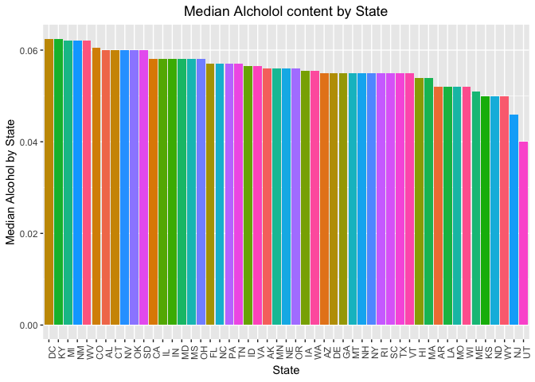

```r
df_ABV_by_State <- df_Beers_Breweries %>% group_by(State) %>% summarise(Median=median(ABV,na.rm=TRUE))
df_IBU_by_State <- df_Beers_Breweries %>% group_by(State) %>% summarise(Median=median(IBU,na.rm=TRUE))


ggplot(df_ABV_by_State, aes(x=reorder(df_ABV_by_State$State,-df_ABV_by_State$Median), y=df_ABV_by_State$Median, fill=df_ABV_by_State$State)) + geom_bar (stat="identity") + xlab("State") + ylab("Median Alcohol by State") + ggtitle("Median Alcholol content by State")  + theme(plot.title = element_text(hjust=.5))+theme(axis.text.x=element_text(angle=90)) + scale_color_gradientn(colours=rainbow(20)) + theme(legend.position="none")
```

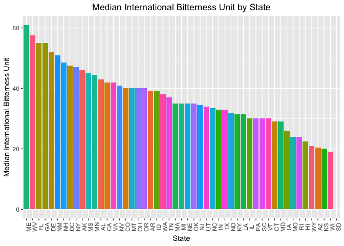

```r
ggplot(df_IBU_by_State, aes(x=reorder(df_IBU_by_State$State,-df_IBU_by_State$Median), y=df_IBU_by_State$Median, fill=df_IBU_by_State$State)) + geom_bar (stat="identity") + xlab("State") + ylab("Median International Bitterness Unit") + ggtitle("Median International Bitterness Unit by State")  + theme(plot.title = element_text(hjust=.5))+theme(axis.text.x=element_text(angle=90)) + scale_color_gradientn(colours=rainbow(20)) + theme(legend.position="none")
```

- Alcohol content did not vary much state by state whereas IBU did have some variation.

## States with the Maximum ABV and IBU?

- The District of Columbia has the highest median for alochol content whereas Maine has the highest IBU.

## Summary statistics for ABV

- This will show the summary statistics for ABV

```r
summary(df_Beers$ABV,na.rm=TRUE)
```

```
##    Min. 1st Qu.  Median    Mean 3rd Qu.    Max.    NA's
## 0.00100 0.05000 0.05600 0.05977 0.06700 0.12800      62
```

- The maximum ABV came to be .128 and the lowest was .00100. I am not sure what the point of drinking that beer would be.

## Relationship between ABV and IBU

- This will plot IBU and ABV in a scatter plot

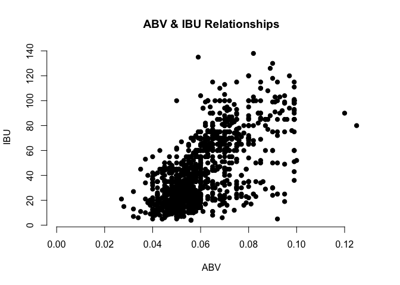

```r
plot(df_Beers$ABV,df_Beers$IBU, main="ABV & IBU Relationships", xlab="ABV",ylab="IBU",pch=19,frame=FALSE)
```

## This calculates the adj r squared to determine the strength of the relationship between ABV and IBU

```r
df_ibu_abv=data.frame(df_Beers_Breweries$ABV,df_Beers_Breweries$IBU)
reg=lm(df_Beers_Breweries.ABV~df_Beers_Breweries.IBU,data=df_ibu_abv)
summary(reg)
```

```
##
## Call:
## lm(formula = df_Beers_Breweries.ABV ~ df_Beers_Breweries.IBU,
##     data = df_ibu_abv)
##
## Residuals:
##       Min        1Q    Median        3Q       Max
## -0.033288 -0.005946 -0.001595  0.004022  0.052006
##
## Coefficients:
##                         Estimate Std. Error t value Pr(>|t|)
## (Intercept)            4.493e-02  5.177e-04   86.79   <2e-16 ***
## df_Beers_Breweries.IBU 3.508e-04  1.036e-05   33.86   <2e-16 ***
## ---
## Signif. codes:  0 '***' 0.001 '**' 0.01 '*' 0.05 '.' 0.1 ' ' 1
##
## Residual standard error: 0.01007 on 1403 degrees of freedom
##   (1005 observations deleted due to missingness)
## Multiple R-squared:  0.4497, Adjusted R-squared:  0.4493
## F-statistic:  1147 on 1 and 1403 DF,  p-value: < 2.2e-16
```

- There seems to be a relationship between ABV and IBU, in which, the less alcohol content there is the less bitter the beer.

# ** Conclusion **

- Although there is a cluster of observations showing some correlation between ABV and IBU however the relantionship on the weaker side. This contends to the variation noticed in the IBU data where there is a lot of “noise” in the data as breweries will tend to make their beer based on consumer demands which would include what type of ingredients are used during the brewing process.